# Function reference and tutorials

Crystal Shan

## Package overview

`selectFiberseqLociWorkflow` visualizes m6A methylation and per-read footprints at selected genomic loci using processed tracks from fibertools and FiberHMM. You choose the samples, methylation and footprint files, genomic coordinates, and footprint length filters. The package produces m6A heatmaps, aggregate m6A profiles and footprint panels, with optional clustering of reads by their m6A patterns.

The required m6A input is fibertools BED12. Optional tracks include fibertools or FiberHMM nucleosomes, FiberHMM or custom per-read TF footprints, and FIRE intervals. Human, plant and other genomes are supported when contig names and reference assemblies agree across inputs. The package reads processed tracks; it does not call methylation or footprints from raw sequencing data.

### Prepare sample inputs

| Function | What it does |
| --- | --- |
| `example_data()` | Load a writable example dataset. |
| `make_sample_sheet()` | Define samples and track paths. |

### Select genomic regions

| Function | What it does |
| --- | --- |
| `prepare_regions()` | Define loci from coordinates or annotations. |
| `extract_canonical_tss()` | Select canonical transcription start sites. |

### Validate and analyze

| Function | What it does |
| --- | --- |
| `validate_inputs()` | Check files, indexes and contigs. |
| `analyze_loci()` | Collect locus data and optionally cluster reads. |

### Summarize and visualize

| Function | What it does |
| --- | --- |
| `locus_profile()` | Summarize pooled or per-cluster m6A. |
| `plot_locus()` | Draw heatmaps, profiles and footprints. |
| `cluster_colors()` | Get consistent cluster colors. |

### Export results

| Function | What it does |
| --- | --- |
| `write_locus_results()` | Save experiments, tables and figures. |

## Before you start

Install the package and its dependencies as described in the README, then load:

```r
library(selectFiberseqLociWorkflow)
library(SummarizedExperiment)
library(GenomicRanges)
```

Examples below execute with bundled files and temporary output directories. Only the clearly marked own-data example needs paths supplied by you.

## Prepare sample inputs: tutorials

### `example_data()` — load test files

This function copies a small subset of real AL6 and AL8 LCL tracks around ALAS1 and PRDX1 into a writable directory. It returns the sample sheet, region ranges and copied directory. These files cover the example loci, not the whole genome.

```r
e <- example_data()
names(e)
```

```
#> [1] "samples"   "regions"   "directory"
```

```r
e$samples[, c("sample_name", "sample_label")]
```

```
#> DataFrame with 2 rows and 2 columns
#>        sample_name sample_label
#>        <character>  <character>
#> 1 AL6_bc2162_19093          AL6
#> 2 AL8_bc2170_19151          AL8
```

```r
e$regions
```

```
#> GRanges object with 2 ranges and 2 metadata columns:
#>         seqnames            ranges strand |   region_id       tss
#>            <Rle>         <IRanges>  <Rle> | <character> <numeric>
#>   ALAS1     chr3 52197160-52199159      + |       ALAS1  52198160
#>   PRDX1     chr1 45520884-45522883      - |       PRDX1  45521884
#>   -------
#>   seqinfo: 2 sequences from an unspecified genome; no seqlengths
```

The default destination is temporary. To keep the files, pass a new or empty folder, for example `example_data("my-fiberseq-example")`.

### `make_sample_sheet()` — specify samples and files

Create one row per sample. `sample_name` is a unique ID; `sample_label` is a display or group label. The required columns are `sample_name`, `m6a` and `m6a_format`. Optional tracks have their own path and format columns.

```r
sample_table <- as.data.frame(e$samples)
sample_file <- tempfile(fileext = ".tsv")
samples <- make_sample_sheet(sample_table, output = sample_file)
samples[, c("sample_name", "sample_label", "m6a_format", "tf_format")]
```

```
#> DataFrame with 2 rows and 4 columns
#>        sample_name sample_label       m6a_format         tf_format
#>        <character>  <character>      <character>       <character>
#> 1 AL6_bc2162_19093          AL6 bed12_fibertools bed15_fiberhmm_tf
#> 2 AL8_bc2170_19151          AL8 bed12_fibertools bed15_fiberhmm_tf
```

```r
# Reload the saved sample sheet in a later session.
samples <- make_sample_sheet(sample_file)
```

To select fewer samples, subset the rows of `sample_table` before calling `make_sample_sheet()`. To use your own files, replace the paths in this example:

```r
sample_table <- data.frame(
    sample_name = c("sample_1", "sample_2"),
    sample_label = c("Control", "Treatment"),
    m6a = "/data/{sample_name}/m6a.{chr}.bed.gz",
    m6a_format = "bed12_fibertools",
    nucleosome = "/data/{sample_name}/nucleosome.{chr}.bed.gz",
    nucleosome_format = "bed13_fiberhmm",
    tf = "/data/{sample_name}/tf.{chr}.bed.gz",
    tf_format = "bed15_fiberhmm_tf"
)
samples <- make_sample_sheet(sample_table, output = "samples.tsv")
```

[output not shown]

Only `{sample_name}` and `{chr}` are supported placeholders. They select existing files; they do not create folders or split files. For a sample table created in R, relative paths start from `base_dir` (the working directory by default).

Each supplied track must be sorted, bgzip-compressed and accompanied by a `.tbi` index. Omit optional columns or leave optional paths blank if no track is available. The supported format strings are:

| Track | Format |
| --- | --- |
| m6A | `bed12_fibertools` |
| Nucleosome | `bed12_fibertools` or `bed13_fiberhmm` |
| TF footprint | `bed15_fiberhmm_tf` or `bed6_per_sample` |
| FIRE | `bed11_fire` |

Custom TF BED6 files use chromosome, zero-based start, end, original read ID, score and strand. They must already be score-filtered. Footprint read IDs must match the m6A read IDs within the same sample.

## Select genomic regions: tutorials

### `prepare_regions()` — choose loci

Use coordinate strings for a quick custom interval. They are one-based and inclusive. This example selects 1,000 bp within the bundled ALAS1 locus:

```r
regions <- prepare_regions("chr3:52197660-52198659")
names(regions) <- "ALAS1_custom"
regions
```

```
#> GRanges object with 1 range and 2 metadata columns:
#>                seqnames            ranges strand |              region_id
#>                   <Rle>         <IRanges>  <Rle> |            <character>
#>   ALAS1_custom     chr3 52197660-52198659      * | chr3_52197659_52198659
#>                      tss
#>                <numeric>
#>   ALAS1_custom        NA
#>   -------
#>   seqinfo: 1 sequence from an unspecified genome; no seqlengths
```

For several loci, supply several strings and give each a unique name. You can also supply a coordinate table, a `GRanges`, a BED file, or a GTF/GFF3 annotation. Contig names are preserved exactly, including case.

The following BED example describes the same interval. BED starts are zero-based and ends are excluded; the region BED needs no tabix index.

```r
bed_file <- tempfile(fileext = ".bed")
write.table(
    data.frame(chr = "chr3", start = 52197659, end = 52198659,
               name = "ALAS1_custom"),
    bed_file, sep = "\t", quote = FALSE, row.names = FALSE, col.names = FALSE
)
regions_from_bed <- prepare_regions(bed_file)
regions_from_bed
```

```
#> GRanges object with 1 range and 2 metadata columns:
#>                seqnames            ranges strand |    region_id       tss
#>                   <Rle>         <IRanges>  <Rle> |  <character> <numeric>
#>   ALAS1_custom     chr3 52197660-52198659      * | ALAS1_custom        NA
#>   -------
#>   seqinfo: 1 sequence from an unspecified genome; no seqlengths
```

```r
stopifnot(identical(start(regions), start(regions_from_bed)),
          identical(end(regions), end(regions_from_bed)))
```

For tables, declare `coordinate_system = "bed"` or `"one_based"` explicitly. For gene-based selection, provide `annotation`, `genes` and `flank_bp`:

```r
# Synthetic plant annotation included to demonstrate GFF3 input.
plant_annotation <- system.file("extdata", "plant", "annotation.gff3",
    package = "selectFiberseqLociWorkflow")
plant_promoters <- prepare_regions(
    annotation = plant_annotation, genes = "AT5G00010", flank_bp = 1000
)
plant_promoters
```

```
#> GRanges object with 2 ranges and 5 metadata columns:
#>                         seqnames    ranges strand |             region_id
#>                            <Rle> <IRanges>  <Rle> |           <character>
#>   AT5G00010_Chr5_2001_+     Chr5 1001-3000      + | AT5G00010_Chr5_2001_+
#>   AT5G00010_Chr5_2201_+     Chr5 1201-3200      + | AT5G00010_Chr5_2201_+
#>                               tss     gene_id   gene_name
#>                         <numeric> <character> <character>
#>   AT5G00010_Chr5_2001_+      2001   AT5G00010   PlantGene
#>   AT5G00010_Chr5_2201_+      2201   AT5G00010   PlantGene
#>                                 transcript_ids
#>                                    <character>
#>   AT5G00010_Chr5_2001_+ AT5G00010.1,AT5G0001..
#>   AT5G00010_Chr5_2201_+            AT5G00010.2
#>   -------
#>   seqinfo: 1 sequence from an unspecified genome; no seqlengths
```

Annotations must contain transcript/mRNA records with gene relationships. Ordinary promoter selection does not require canonical tags. A flank of 1,000 selects one-based `[TSS - 1000, TSS + 999]`. The plant annotation above is a separate illustration; continue using `regions` with the LCL sample sheet.

### `extract_canonical_tss()` — select canonical TSSs

Use this optional function when you specifically want canonical transcripts. Specify the attribute and value used by your annotation; the defaults look for GENCODE’s `tag = Ensembl_canonical`. Missing or ambiguous canonical selections raise an error.

```r
canonical_tss <- extract_canonical_tss(
    annotation = plant_annotation,
    genes = "AT5G00010",
    attribute = "canonical", value = "true", flank_bp = 0
)
canonical_tss
```

```
#> GRanges object with 1 range and 5 metadata columns:
#>                         seqnames    ranges strand |             region_id
#>                            <Rle> <IRanges>  <Rle> |           <character>
#>   AT5G00010_Chr5_2001_+     Chr5      2001      + | AT5G00010_Chr5_2001_+
#>                               tss     gene_id   gene_name transcript_ids
#>                         <numeric> <character> <character>    <character>
#>   AT5G00010_Chr5_2001_+      2001   AT5G00010   PlantGene    AT5G00010.1
#>   -------
#>   seqinfo: 1 sequence from an unspecified genome; no seqlengths
```

`flank_bp = 0` returns the single TSS base. A positive flank returns a region around it, ready for validation and analysis against matching tracks.

## Validate and analyze: tutorials

### `validate_inputs()` — check the inputs

Check track paths, adjacent indexes, declared column counts and m6A contig availability before analyzing. Success returns `TRUE` invisibly; an invalid input raises an error describing the problem.

```r
valid <- validate_inputs(samples, regions)
valid
```

```
#> [1] TRUE
```

An optional track may have no calls on the selected contig. A supplied path to a missing file is an error. All files and coordinates must use the same genome assembly; validation cannot determine the biological assembly from names alone.

### `analyze_loci()` — collect calls and cluster reads

Start without clustering. Here, `tf_length_ranges = NULL` retains all positive TF lengths after the applicable score filter:

```r
unclustered <- analyze_loci(
    samples, regions, clustering = FALSE,
    nuc_min = 130, nuc_max = 160,
    min_tf_score = 50, tf_length_ranges = NULL,
    smoothing_bp = 10
)
x <- unclustered[["ALAS1_custom"]]
x
```

```
#> class: RangedSummarizedExperiment
#> dim: 1000 18
#> metadata(7): region samples ... empty_footprint_tracks package_version
#> assays(1): m6a
#> rownames(1000): chr3:52197660 chr3:52197661 ... chr3:52198658
#>   chr3:52198659
#> rowData names(0):
#> colnames(18): AL6_bc2162_19093::m84241_250514_222554_s2/132252921/ccs
#>   AL6_bc2162_19093::m84241_250514_222554_s2/265817825/ccs ...
#>   AL8_bc2170_19151::m84241_250325_230544_s1/189993650/ccs
#>   AL8_bc2170_19151::m84241_250325_230544_s1/87559118/ccs
#> colData names(11): RID original_RID ... read_range footprints
```

```r
dim(assay(x, "m6a"))
```

```
#> [1] 1000   18
```

The result is a named list of locus experiments. Each sparse assay has genomic positions in rows and reads in columns. `colData(x)` contains read metadata and per-read footprint ranges. Only reads whose longest overlapping alignment spans the complete locus are retained, including reads with zero m6A calls.

For custom TF length filters, pass `list(c(30, 39), c(80, 120))` for inclusive 30–39 and 80–120 bp classes, or `list(c(35, 35))` for exactly 35 bp. Ranges must have positive integer bounds and must not overlap. Omitting the argument preserves the default 10–29, 40–59 and 60–79 bp classes. Both TF formats use the same length filtering; only FiberHMM BED15 uses `min_tf_score`.

Run the same locus with clustering enabled:

```r
clustered <- analyze_loci(
    samples, regions, clustering = TRUE,
    window_size = 50, k_neighbors = 5, resolution = 0.5, seed = 1,
    nuc_min = 130, nuc_max = 160,
    min_tf_score = 50, tf_length_ranges = NULL,
    smoothing_bp = 10
)
xc <- clustered[["ALAS1_custom"]]
S4Vectors::metadata(xc)$clustering_status
```

```
#> [1] "complete"
```

```r
stopifnot(identical(S4Vectors::metadata(xc)$clustering_status, "complete"))
table(sample = colData(xc)$sample_label, cluster = colData(xc)$cluster)
```

```
#>       cluster
#> sample cluster1
#>    AL6        8
#>    AL8       10
```

`window_size` sets clustering bins in bp (`0` uses observed sites without binning), `k_neighbors` sets the nearest-neighbor count, `resolution` controls Leiden partition granularity, and `seed` controls randomness. Larger resolution values generally favor more clusters. These illustrative settings are not optimized biological parameters.

Clustering uses m6A patterns across the supplied samples at each locus. It needs at least three reads and two occupied features; otherwise, metadata explain why it was skipped. Exact Manhattan distances require memory quadratic in the number of reads. Footprint filters do not affect the m6A fit. Binning does not change the stored single-base assay, and `smoothing_bp` independently controls profile smoothing.

## Summarize and visualize: tutorials

### `locus_profile()` — summarize m6A calls

Calculate a pooled profile from all retained reads, or separate profiles by cluster. `frac` is the observed-call fraction and `smooth_frac` is its smoothed value. Zero-call reads remain in the denominator.

```r
pooled_profile <- locus_profile(x)
head(pooled_profile)
```

```
#> DataFrame with 6 rows and 8 columns
#>         pos        base       group       cov       met      frac smooth_cov
#>   <integer> <character> <character> <integer> <numeric> <numeric>  <integer>
#> 1  52197661           A         All        18         1 0.0555556         18
#> 2  52197688           A         All        18         1 0.0555556         18
#> 3  52197702           A         All        18         1 0.0555556         18
#> 4  52197705           A         All        18         1 0.0555556         18
#> 5  52197706           A         All        18         1 0.0555556         18
#> 6  52197712           A         All        18         1 0.0555556         18
#>   smooth_frac
#>     <numeric>
#> 1   0.0555556
#> 2   0.0555556
#> 3   0.0555556
#> 4   0.0555556
#> 5   0.0555556
#> 6   0.0555556
```

```r
cluster_profiles <- locus_profile(xc, by_cluster = TRUE)
head(cluster_profiles)
```

```
#> DataFrame with 6 rows and 8 columns
#>         pos        base       group       cov       met      frac smooth_cov
#>   <integer> <character> <character> <integer> <numeric> <numeric>  <integer>
#> 1  52197661           A    cluster1        18         1 0.0555556         18
#> 2  52197688           A    cluster1        18         1 0.0555556         18
#> 3  52197702           A    cluster1        18         1 0.0555556         18
#> 4  52197705           A    cluster1        18         1 0.0555556         18
#> 5  52197706           A    cluster1        18         1 0.0555556         18
#> 6  52197712           A    cluster1        18         1 0.0555556         18
#>   smooth_frac
#>     <numeric>
#> 1   0.0555556
#> 2   0.0555556
#> 3   0.0555556
#> 4   0.0555556
#> 5   0.0555556
#> 6   0.0555556
```

```r
# Clustering leaves the pooled profile unchanged.
stopifnot(identical(pooled_profile, locus_profile(xc)))
```

Sparse zeros indicate no observed m6A call, not a direct measurement of an unmethylated adenine at every genomic base. Subsetting reads in an experiment and calling `locus_profile()` recomputes the profile for those reads.

### `plot_locus()` — draw locus figures

Choose `"heatmap"`, `"profile"` or `"footprints"`. The heatmap shows reads on the y-axis and positions on the x-axis. The footprint composition stacks the m6A profile, m6A reads and supplied footprint tracks.

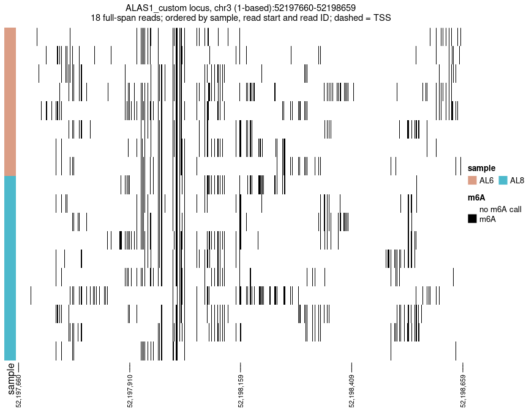

```r
ComplexHeatmap::draw(plot_locus(x, "heatmap"))
```

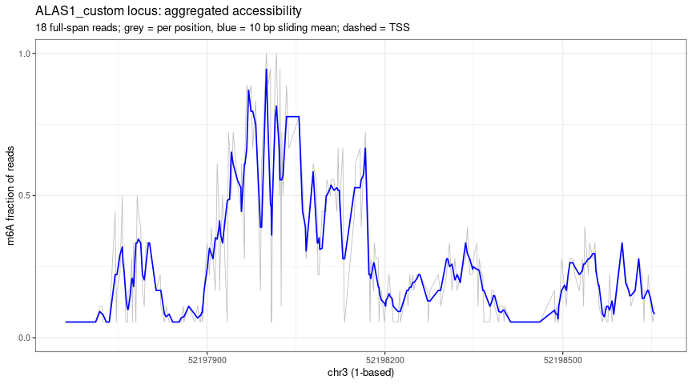

```r
plot_locus(x, "profile")
```

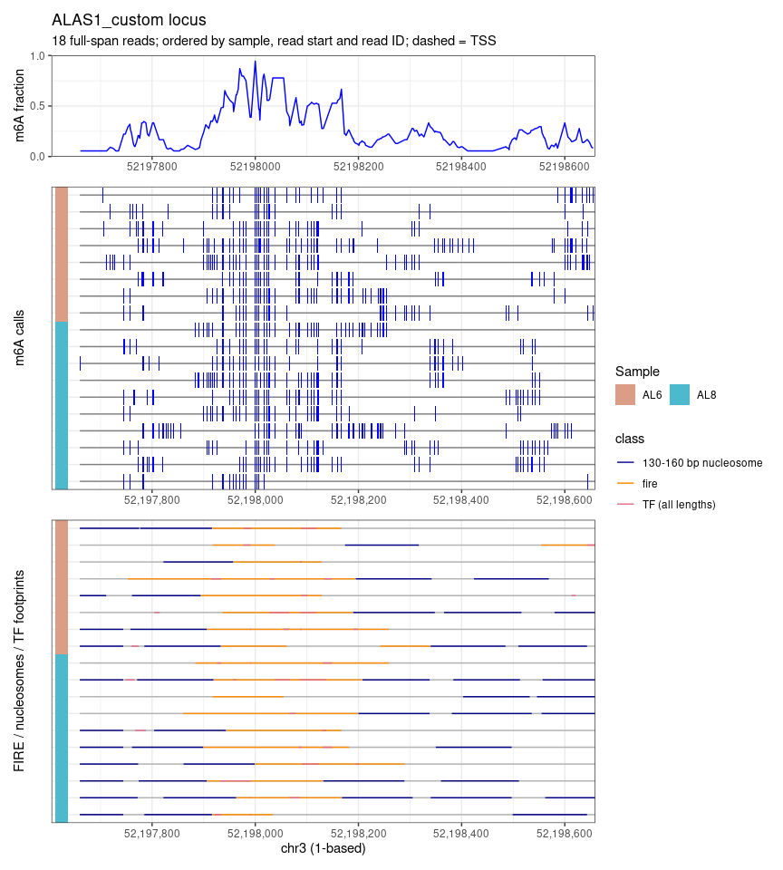

```r
plot_locus(x, "footprints")
```

Use `clustered = TRUE` to order reads by existing assignments and display per-cluster profiles. This does not rerun clustering.

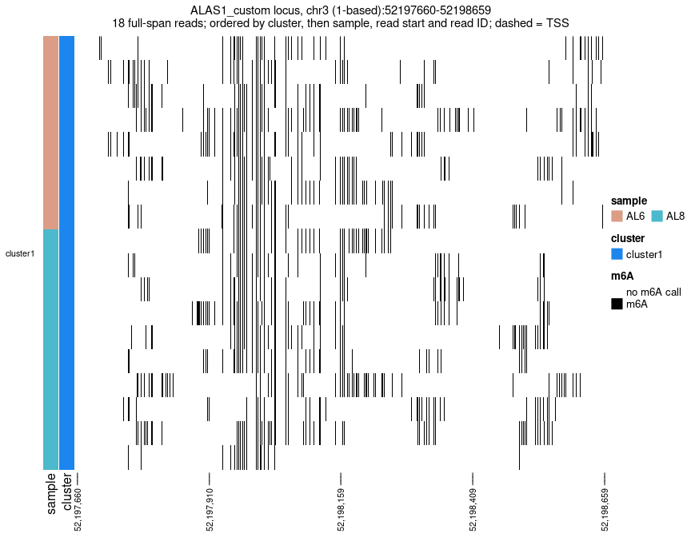

```r
ComplexHeatmap::draw(plot_locus(xc, "heatmap", clustered = TRUE))
```

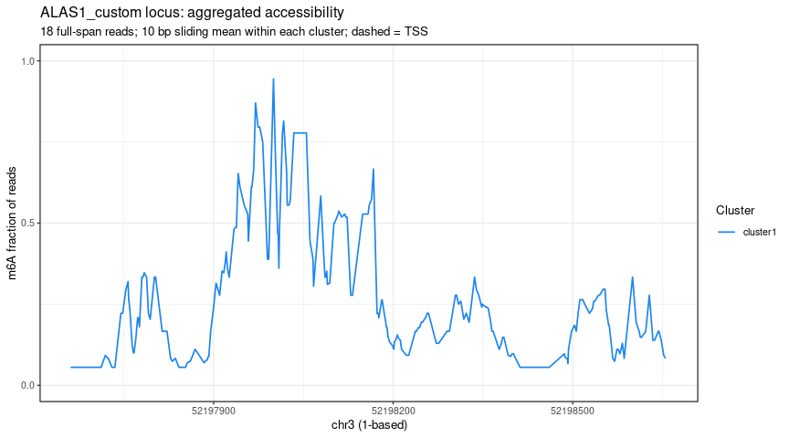

```r
plot_locus(xc, "profile", clustered = TRUE)
```

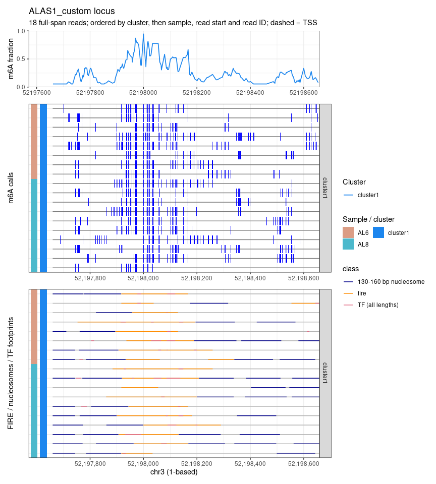

```r
plot_locus(xc, "footprints", clustered = TRUE)
```

Custom TF ranges receive labels and colors automatically. If supplied nucleosome or TF tracks contain no retained calls, analysis emits `no footprints called in the selected region` and continues. Check read IDs, length bounds and score thresholds when calls were expected.

### `cluster_colors()` — reuse cluster colors

Retrieve the plotting palette for cluster labels or factor levels. Use it to keep your own figures consistent with the locus plots.

```r
palette <- cluster_colors(colData(xc)$cluster)
palette
```

```
#>      cluster1
#> "dodgerblue2"
```

```r
# Named colors can also be requested directly.
cluster_colors(c("cluster1", "cluster2", "cluster3"))
```

```
#>      cluster1      cluster2      cluster3
#> "dodgerblue2"     "#E31A1C"      "green4"
```

Numeric cluster IDs retain their colors when a cluster is absent from a subset. Keep complete factor levels for palettes containing more than 25 clusters.

## Export results: tutorial

### `write_locus_results()` — save the analysis

Pass a single locus experiment or the complete results list, and choose a new or empty output directory. This example exports all loci from the clustered run, including both unclustered and clustered views:

```r
output_dir <- tempfile("fiberseq-reference-results-")
write_locus_results(clustered, output_dir)
list.files(output_dir, recursive = TRUE)
```

```
#>  [1] "ALAS1_custom/clustered/accessibility_profile.tsv"
#>  [2] "ALAS1_custom/clustered/aggregate_m6a_profile.pdf"
#>  [3] "ALAS1_custom/clustered/assignments.tsv"
#>  [4] "ALAS1_custom/clustered/edges.tsv"
#>  [5] "ALAS1_custom/clustered/footprint_tracks.pdf"
#>  [6] "ALAS1_custom/clustered/m6a_heatmap.pdf"
#>  [7] "ALAS1_custom/clustered/manifest.tsv"
#>  [8] "ALAS1_custom/clustered/read_order.tsv"
#>  [9] "ALAS1_custom/locus.rds"
#> [10] "ALAS1_custom/m6a_matrix.rds"
#> [11] "ALAS1_custom/qc.tsv"
#> [12] "ALAS1_custom/reads.tsv"
#> [13] "ALAS1_custom/region.tsv"
#> [14] "ALAS1_custom/unclustered/accessibility_profile.tsv"
#> [15] "ALAS1_custom/unclustered/aggregate_m6a_profile.pdf"
#> [16] "ALAS1_custom/unclustered/footprint_tracks.pdf"
#> [17] "ALAS1_custom/unclustered/m6a_heatmap.pdf"
#> [18] "ALAS1_custom/unclustered/manifest.tsv"
#> [19] "ALAS1_custom/unclustered/read_order.tsv"
```

Each locus directory includes `locus.rds`, `m6a_matrix.rds`, read/QC/region TSVs, and PDF figures. Successful clustering adds assignments and graph edges. Replace `tempfile()` with a persistent folder to keep the results.

```r
restored <- readRDS(file.path(output_dir, "ALAS1_custom", "locus.rds"))
stopifnot(identical(assay(restored), assay(xc)),
          identical(colData(restored), colData(xc)))
```

Reload `locus.rds` to retain the full experiment, including footprints and run parameters. The matrix-only RDS does not contain that additional information.